# Coursera Machine Learning Project

The goal of your project is to predict how well training exercises were performed. The data provides data from 6 paticipants on 5 different ways to performa the training exercise. Refer to the weight lifting section on http://groupware.les.inf.puc-rio.br/har for more information.

The report below outlines how data is retrieved, cleaned up, and analyzed to provide the prediction for the testing set.

# Loading and Cleaning Data

After loading the data, I cleaned up the data to remove:

- The first 7 columns since they are not predictor variables.
- 67 columns that have high number of NAs (97.9% of their values).
- 9 columns with 1 to 4 factors that contain #DIV/0.
- 33 columns that have high number of Blanks (97.9% of their values).

```r
# load libraries
library(caret)

# retrieving the training and test data sets
trainingData <- read.csv("https://d396qusza40orc.cloudfront.net/predmachlearn/pml-training.csv")
predictData <- read.csv("https://d396qusza40orc.cloudfront.net/predmachlearn/pml-testing.csv")

# remove the first 7 columns since they are NOT predictor variables
print(colnames(trainingData[1:7]))
```

```
## [1] "X"                    "user_name"            "raw_timestamp_part_1"
## [4] "raw_timestamp_part_2" "cvtd_timestamp"       "new_window"
## [7] "num_window"
```

```r
cleanTrain <- trainingData[, 8:ncol(trainingData)]
cleanPredict <- predictData[, 8:ncol(predictData)]

#remove all columns with NA, Blanks, and ones that have factors including #DIV/0
NACols <- data.frame(Variable=colnames(cleanTrain),
                 NA_Count=sapply(cleanTrain, function(x) {sum(is.na(x))}),
                 NumFactors=sapply(cleanTrain, function(x) {return(nlevels(x))}),
                 Blanks=sapply(cleanTrain, function(x) { return(sum(x==""))}))
NACols$NA_Percent <- round((NACols$NA_Count/nrow(cleanTrain))*100 , 1)
NACols$Blank_Percent <- round((NACols$Blanks/nrow(cleanTrain))*100 , 1)
NACols$OneToFourFactors <- (NACols$NumFactors>0 & NACols$NumFactors<=4)
# Number of columns and percentage of NAs
DF <- as.data.frame(table(NACols$NA_Percent)); colnames(DF) <- c("NA_Percent", "Column_Count"); DF
```

```
##   NA_Percent Column_Count
## 1          0           86
## 2       97.9           67
```

```r
# Number of columns and persentage of Blanks
DF <- as.data.frame(table(NACols$Blank_Percent)); colnames(DF) <- c("Blank_Percent", "Column_Count"); DF
```

```
##   Blank_Percent Column_Count
## 1             0           53
## 2          97.9           33
```

```r
# number of factor columns with #DIV/0 to remove
DF <- as.data.frame(table(NACols$OneToFourFactors)); colnames(DF) <- c("OneToFourFactors", "Column_Count"); DF
```

```
##   OneToFourFactors Column_Count
## 1            FALSE          144
## 2             TRUE            9
```

```r
# remove columns from data set
goodColsIndex <- which(NACols$NA_Count==0 & (NACols$NumFactors==0 | NACols$NumFactors>4) & (NACols$Blanks==0))
cleanTrain <- cleanTrain[, goodColsIndex]
cleanPredict <- cleanPredict[, goodColsIndex]
```

# Splitting the Data into Training and Test sets

60% of the data for training, and 40% for testing

```r
# split the data into inTrain & inTest
inTrain <- createDataPartition(y=cleanTrain$classe, p=0.6, list=FALSE)
train <- cleanTrain[inTrain, ]
test  <- cleanTrain[-inTrain, ]
```

# Create the Prediction Model using GBM (Gradient Boosting Model)

- I used GBM since it is a good machine learning technique for regression and classification problems that produces a model from multiple variables in the form of decision trees.
- At n.tree=150: Accuracy=0.95, and Kappa=0.94. The high value of accuracy and kappa demontrates that the predictive model is acceptable.

```r
# use gbm to build the prediction model
## added the if statement below to avoid running the train function every time while I finish up the write up.
set.seed(2355)
if (file.exists("GBM.RDATA")==TRUE)
{
  print("Loading data model from file.")
  load("GBM.RDATA")
} else
{
  print("Creating the data model.")
  gbmFit <- train(classe~., data=train, method="gbm", verbose=FALSE)
  save(gbmFit, file="GBM.RDATA")
}
```

```
## [1] "Creating the data model."
```

```r
# view model
print(gbmFit)
```

```
## Stochastic Gradient Boosting
##
## 11776 samples
##    52 predictor
##     5 classes: 'A', 'B', 'C', 'D', 'E'
##
## No pre-processing
## Resampling: Bootstrapped (25 reps)
## Summary of sample sizes: 11776, 11776, 11776, 11776, 11776, 11776, ...
## Resampling results across tuning parameters:
##
##   interaction.depth  n.trees  Accuracy   Kappa      Accuracy SD
##   1                   50      0.7432269  0.6742355  0.006588475
##   1                  100      0.8127737  0.7629212  0.005714018
##   1                  150      0.8457091  0.8046742  0.005779431
##   2                   50      0.8496949  0.8095205  0.006023301
##   2                  100      0.9019071  0.8758393  0.004928160
##   2                  150      0.9261570  0.9065547  0.004554796
##   3                   50      0.8911680  0.8622122  0.004371521
##   3                  100      0.9356912  0.9186246  0.004200055
##   3                  150      0.9554064  0.9435749  0.002061193
##   Kappa SD
##   0.008445642
##   0.007236856
##   0.007356663
##   0.007671443
##   0.006292327
##   0.005835952
##   0.005610622
##   0.005343982
##   0.002639153
##
## Tuning parameter 'shrinkage' was held constant at a value of 0.1
##
## Tuning parameter 'n.minobsinnode' was held constant at a value of 10
## Accuracy was used to select the optimal model using  the largest value.
## The final values used for the model were n.trees = 150,
##  interaction.depth = 3, shrinkage = 0.1 and n.minobsinnode = 10.
```

# Evaluate the Model: Out of Sample Error

Summary:

- Accuracy is 0.97 and Kappa is 0.96
- Around 97% of the evaluation samples are predicted correctly.

```r
# predict the test set for evaluation
predictGBMTest <- predict(gbmFit, test)

# view prediction results
confusionMatrix(predictGBMTest,test$classe)
```

```
## Confusion Matrix and Statistics
##
##           Reference
## Prediction    A    B    C    D    E
##          A 2202   67    0    2    2
##          B   23 1415   37    3    6
##          C    5   34 1308   28   10
##          D    2    2   21 1241   14
##          E    0    0    2   12 1410
##
## Overall Statistics
##
##                Accuracy : 0.9656
##                  95% CI : (0.9613, 0.9695)
##     No Information Rate : 0.2845
##     P-Value [Acc > NIR] : < 2.2e-16
##
##                   Kappa : 0.9564
##  Mcnemar's Test P-Value : 9.883e-06
##
## Statistics by Class:
##
##                      Class: A Class: B Class: C Class: D Class: E
## Sensitivity            0.9866   0.9321   0.9561   0.9650   0.9778
## Specificity            0.9874   0.9891   0.9881   0.9941   0.9978
## Pos Pred Value         0.9688   0.9535   0.9444   0.9695   0.9902
## Neg Pred Value         0.9946   0.9838   0.9907   0.9931   0.9950
## Prevalence             0.2845   0.1935   0.1744   0.1639   0.1838
## Detection Rate         0.2807   0.1803   0.1667   0.1582   0.1797
## Detection Prevalence   0.2897   0.1891   0.1765   0.1631   0.1815
## Balanced Accuracy      0.9870   0.9606   0.9721   0.9795   0.9878
```

### Out Of Sample Error

```r
# Out of Sample Errors
test$predRight <- (predictGBMTest==test$classe)
DF <- as.data.frame(table(test$predRight)); colnames(DF) <- c("Right_Prediction", "Count")
DF$Percentage <- round((DF$Count / sum(DF$Count)) * 100.0, 1) ; DF
```

```
##   Right_Prediction Count Percentage
## 1            FALSE   270        3.4
## 2             TRUE  7576       96.6
```

### Actual vs. Predicted

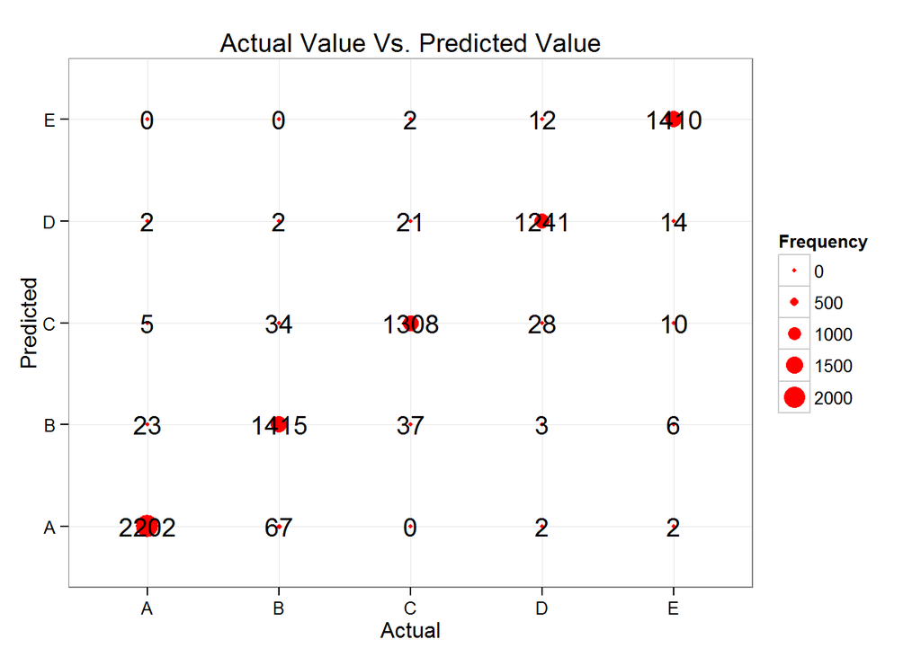

```r
# chart the prediction vs. Actual
DF <- as.data.frame(table(predictGBMTest, test$classe))
colnames(DF) <- c("Predicted", "Actual", "Frequency")
g <- ggplot(DF, aes(x=Actual, y=Predicted))
g <- g + geom_point(aes(size=Frequency), colour="red")
g <- g + geom_text(aes(label=Frequency), colour="black")
g <- g + ggtitle("Actual Value Vs. Predicted Value") + xlab("Actual") + ylab("Predicted")
g <- g + theme_bw()
print(g)
```

# Final Model

Below are:

- The list of columns by importance to the model
- summary of the final model

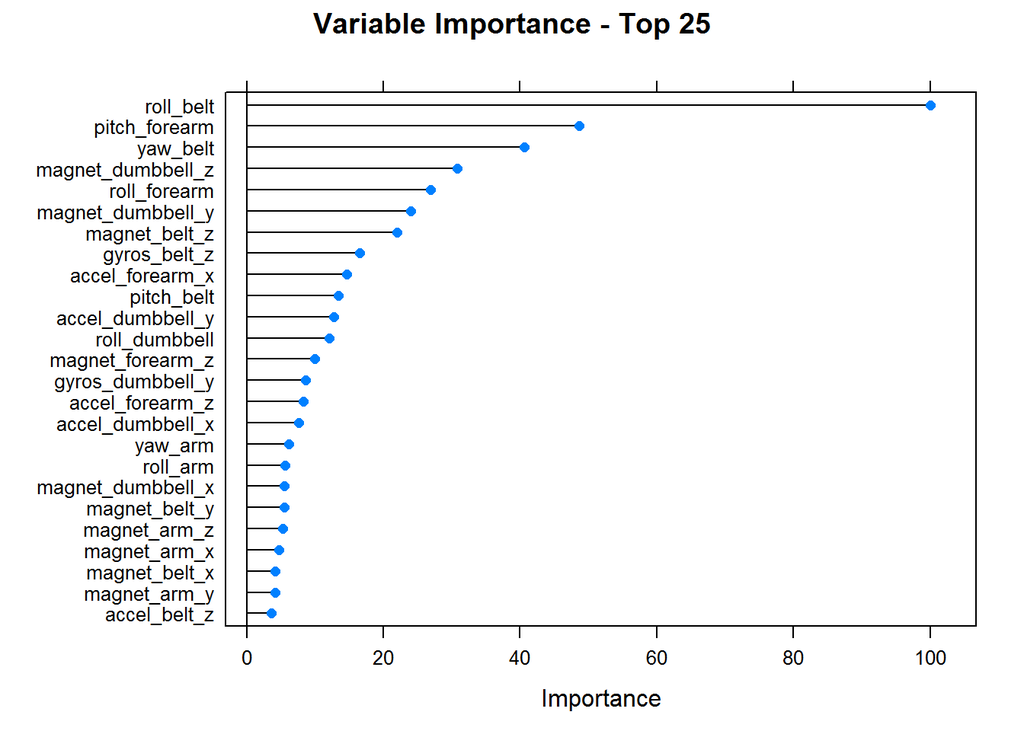

```r
# plot variables by importance
plot(varImp(gbmFit), main = "Variable Importance - Top 25", top = 25)
```

```r
# sumary of final model
gbmFit$finalModel
```

```
## A gradient boosted model with multinomial loss function.
## 150 iterations were performed.
## There were 52 predictors of which 42 had non-zero influence.
```

# Use the Model to predict the 20 testing cases

```r
# predict the test set for evaluation
predictGBM <- predict(gbmFit, cleanPredict)
print(data.frame(Predicted_classe=predictGBM))
```

```
##    Predicted_classe
## 1                 B
## 2                 A
## 3                 B
## 4                 A
## 5                 A
## 6                 E
## 7                 D
## 8                 B
## 9                 A
## 10                A
## 11                B
## 12                C
## 13                B
## 14                A
## 15                E
## 16                E
## 17                A
## 18                B
## 19                B
## 20                B
```

```r
# counts per classe type
DF <- as.data.frame(table(predictGBM)); colnames(DF) <- c("Predicted_Value", "Count");
DF$Percentage <- round((DF$Count / sum(DF$Count)) * 100.0, 1) ; DF
```

```
##   Predicted_Value Count Percentage
## 1               A     7         35
## 2               B     8         40
## 3               C     1          5
## 4               D     1          5
## 5               E     3         15
```